# Stat 11 Week 3

Practice with Data: Modeling Two Numeric Variables

Prof. Suzy Thornton

# 1. Data Introduction

Wildlife researchers are monitoring a Florida alligator population by taking areal photographs and attempting to estimate the weights of the gators based on the length of the gators in the images. The data set `Gators.csv` contains the variables `Length` and `Weight` for a sample of alligators who have been captured and studied.

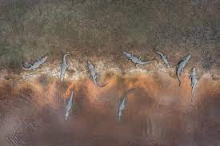

[figure not shown]

# 2. Analysis Goal

We are going to design a simple linear regression model and then assess the model fit and interpretation. Click this link to view the [worksheet for this gator data analysis problem](https://profsuzy.github.io/Stat11/wk3-wksheet.html).

- To open this data set in RStudio you’ll need the following code:

```r
gators <- read.csv("https://raw.githubusercontent.com/ProfSuzy/Stat11/main/Data/Gators.csv")
```

- To open this data set in Excel go to the [link to download the Gator data set](https://github.com/ProfSuzy/Stat11/blob/main/Data/Gators.csv). Right click on the button called “Raw” and select “Save Link As”. Erase the pre-filled name - and file extension! - and fill in “Gators.xlsx” and select “Save”. Then navigate to this file and open it in Microsoft Excel (NOT Apple Numbers and NOT Google Sheets, although they are pretty much the same thing in practice).

## R code for SLR models

After importing your data, you can fit a simple linear regression model by using the following code.

```r
slr <- lm(<response> ~ <predictor>)
```

You can then see all the details of your linear model by using the summary function.

```r
summary(slr)
```

Finally, to create a plot of your data with the linear regression line overlayed, use the following code.

```r
plot(<predictor> , <response>)
abline(slr)
```

# 3. Summary of Results

- It’s important to consider the roles of the explanatory variable and the response variable.
- Just because R (or Excel) fits a line and gives us a slope and intercept doesn’t mean that the model is appropriate or information. We must consider the assumptions for a SLR model:
  - the relationship between predictor and response is **linear enough**
  - there is **no thickening or thinning** of the scatterplot when read from left to right
  - there are **no outliers**

Note, we have not yet had time in class to discuss the phenomena of *regression to the mean* or the issues posed by *lurking variables*. You are still responsible for understanding this material. (These might be good topics for us to cover during the review days before Quiz 1.)